# 5100 Project Q8

Bilal Malik

2025-11-24

# Are there significant differences in trust toward financial institutions across racial/ethnic groups?

## Libraries

```r
library(tidyverse)
```

```r
library(haven)
library(dplyr)
library(ggplot2)
library(boot)
library(lubridate)
library(stringr)
library(naniar)
library(zoo)
library(tseries)
library(forecast)
```

## Data Import

```r
gss <- read_sav("./data/GSS_spss/gss7224_r2.sav")

gss_clean <- gss %>%
  filter(!is.na(confinan)) %>%
  mutate(
    race_cat = case_when(
      race == 1 ~ "White",
      race == 2 ~ "Black",
      race == 3 ~ "Other",
      TRUE      ~ NA_character_
    ),
    ethnicity_binary = case_when(
      hispanic == 1 ~ "Not Hispanic",
      hispanic %in% 2:5 ~ "Hispanic",
      TRUE ~ NA_character_
    )
  ) %>%
  select(confinan, race_cat, ethnicity_binary, year)

gss_clean <- gss_clean %>%
  filter(!is.na(race_cat) & !is.na(ethnicity_binary))

gss_clean$year <- as.numeric(gss_clean$year)
```

## EDA

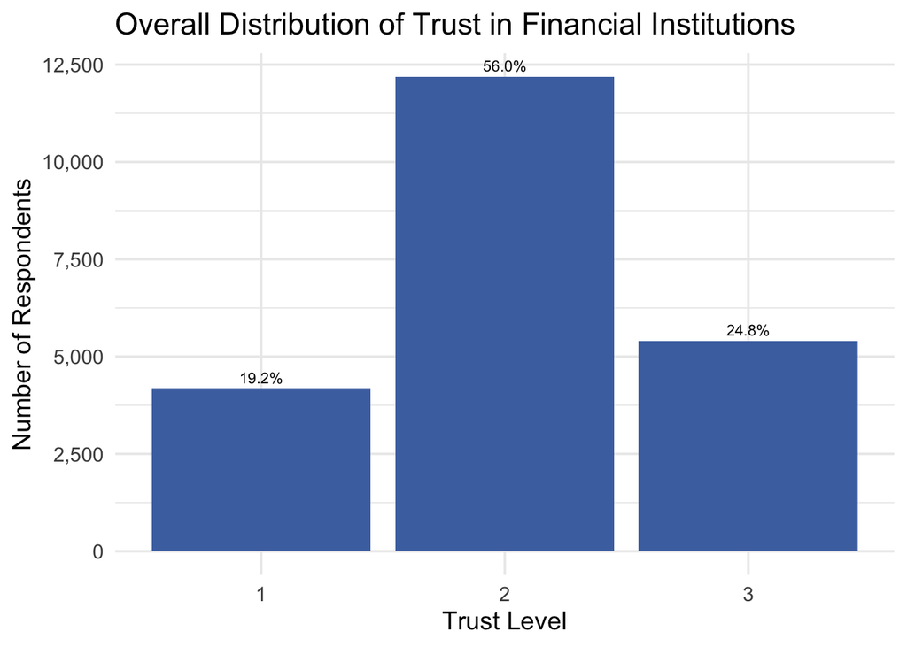

```r
ggplot(gss_clean, aes(x = factor(confinan))) +
  geom_bar(fill = "#4C72B0") +
  geom_text(aes(label = scales::percent(..count../sum(..count..))),
            stat = "count", vjust = -0.5, size = 3) +
  scale_y_continuous(labels = scales::comma) +
  labs(
    title = "Overall Distribution of Trust in Financial Institutions",
    x = "Trust Level",
    y = "Number of Respondents"
  ) +
  theme_minimal(base_size = 14)
```

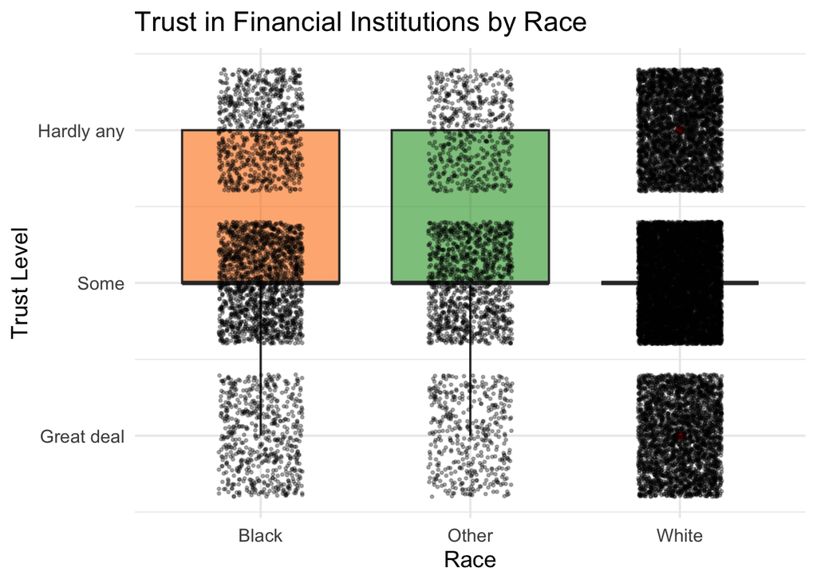

```r
ggplot(gss_clean, aes(x = race_cat, y = confinan, fill = race_cat)) +
  geom_boxplot(outlier.color = "red", alpha = 0.6) +
  geom_jitter(width = 0.2, alpha = 0.3, color = "black", size = 0.5) +
  scale_y_continuous(breaks = 1:3, labels = c("Great deal", "Some", "Hardly any")) +
  scale_fill_manual(values = c("White" = "#1F77B4", "Black" = "#FF7F0E", "Other" = "#2CA02C")) +
  labs(
    title = "Trust in Financial Institutions by Race",
    x = "Race",
    y = "Trust Level"
  ) +
  theme_minimal(base_size = 14) +
  theme(legend.position = "none")
```

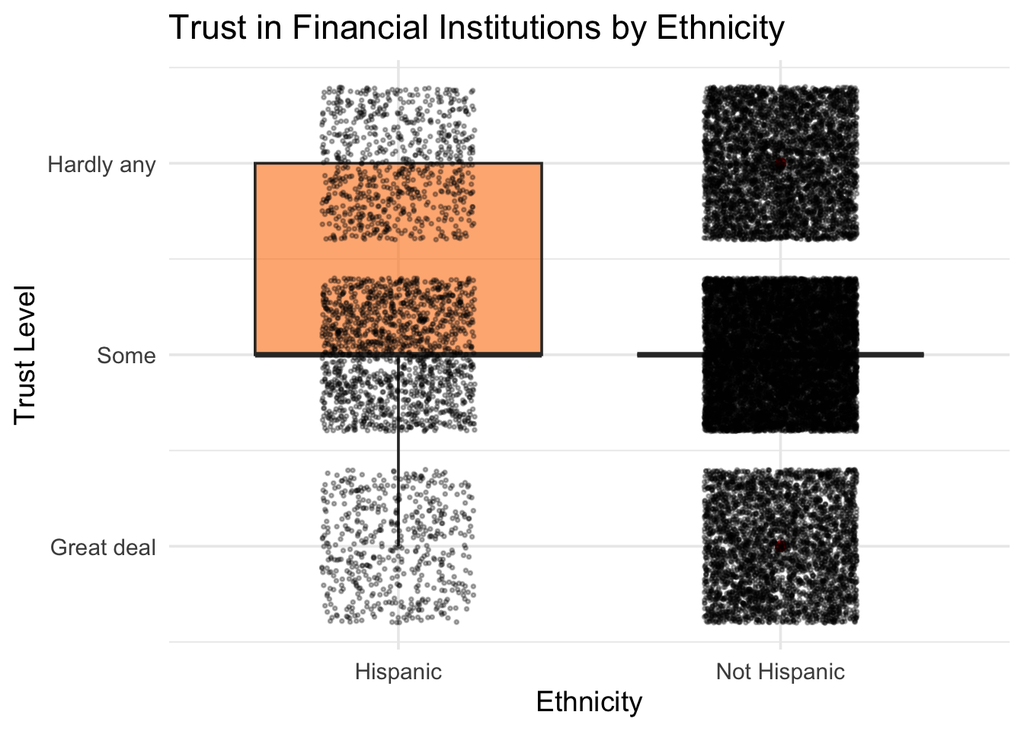

```r
ggplot(gss_clean, aes(x = ethnicity_binary, y = confinan, fill = ethnicity_binary)) +
  geom_boxplot(outlier.color = "red", alpha = 0.6) +
  geom_jitter(width = 0.2, alpha = 0.3, color = "black", size = 0.5) +
  scale_y_continuous(breaks = 1:3, labels = c("Great deal", "Some", "Hardly any")) +
  scale_fill_manual(values = c("Not Hispanic" = "#1F77B4", "Hispanic" = "#FF7F0E")) +
  labs(
    title = "Trust in Financial Institutions by Ethnicity",
    x = "Ethnicity",
    y = "Trust Level"
  ) +
  theme_minimal(base_size = 14) +
  theme(legend.position = "none")
```

The box plot suggests a more pronounced difference when comparing trust by ethnicity. The distribution for **Hispanic** respondents appears shifted toward **lower trust levels**. The IQR for the Hispanic group is visibly wider and centered closer to the boundary between “Some” and “Hardly any,” indicating a **greater spread** and a **lower central tendency** of trust compared to the “Not Hispanic” group, whose median is firmly at “Some” trust.

## Chi-square tests: Trust Levels across Groups

### Race

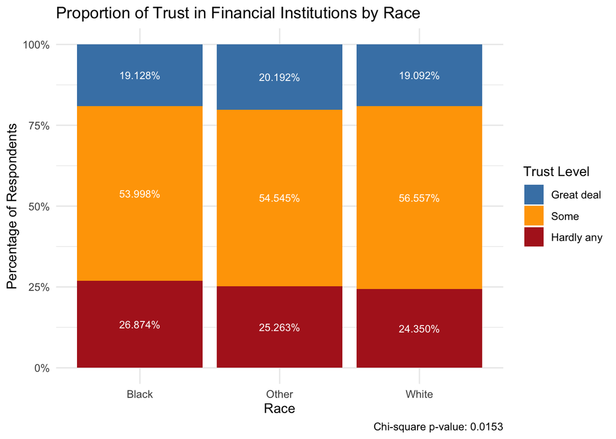

```r
race_prop <- gss_clean %>%
  filter(!is.na(race_cat)) %>%
  group_by(race_cat, confinan) %>%
  summarise(count = n(), .groups = "drop") %>%
  group_by(race_cat) %>%
  mutate(prop = count / sum(count)) %>%
  ungroup()

race_table <- table(gss_clean$confinan, gss_clean$race_cat)
chisq_race <- chisq.test(race_table)

ggplot(race_prop, aes(x = race_cat, y = prop, fill = factor(confinan, levels = c(1,2,3)))) +
  geom_bar(stat = "identity", position = "stack") +
  geom_text(aes(label = scales::percent(prop)),
            position = position_stack(vjust = 0.5), color = "white", size = 3) +
  scale_y_continuous(labels = scales::percent_format()) +
  scale_fill_manual(values = c("steelblue", "orange", "firebrick"),
                    labels = c("Great deal", "Some", "Hardly any")) +
  labs(
    title = "Proportion of Trust in Financial Institutions by Race",
    x = "Race",
    y = "Percentage of Respondents",
    fill = "Trust Level",
    caption = paste("Chi-square p-value:", signif(chisq_race$p.value, 3))
  ) +
  theme_minimal()
```

The Chi-squared test for **Race** (race_cat) resulted in a **significant p-value of** 0.0153. Since this is less than α=0.05, we **reject the null hypothesis** and conclude there is a statistically significant association between a respondent’s race and their level of trust in financial institutions.  
1. **Takeaway (Low Trust):** The stacked bar chart shows that the statistical difference is driven by the extremes. The **Black** group has the **highest proportion** of respondents reporting **“Hardly any” trust** at 26.874%, compared to 24.350% for White respondents.  
2. **Takeaway (High Trust):** The **White** group has the **lowest proportion** of those reporting “Hardly any” trust and the highest proportion of those reporting **“Some” trust** (56.557%).

### Ethnicity

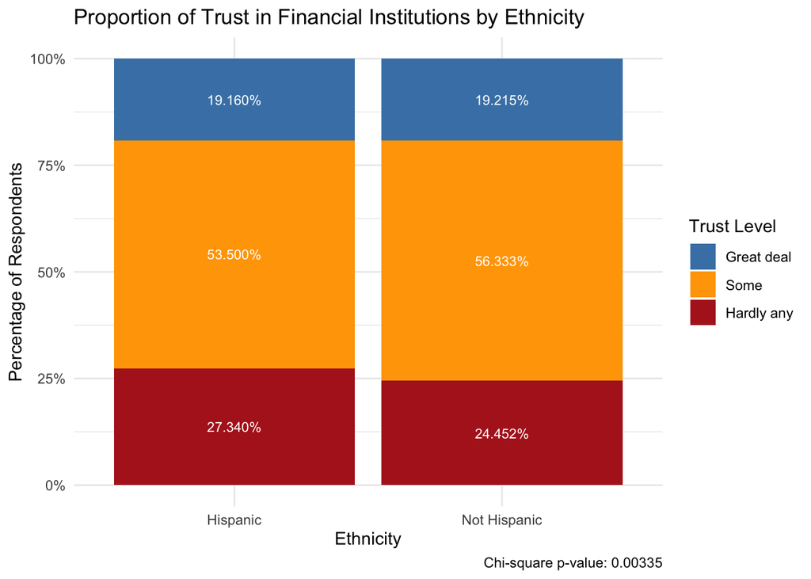

```r
eth_prop <- gss_clean %>%
  filter(!is.na(ethnicity_binary)) %>%
  group_by(ethnicity_binary, confinan) %>%
  summarise(count = n(), .groups = "drop") %>%
  group_by(ethnicity_binary) %>%
  mutate(prop = count / sum(count)) %>%
  ungroup()

eth_table <- table(gss_clean$confinan, gss_clean$ethnicity_binary)
chisq_eth <- chisq.test(eth_table)

ggplot(eth_prop, aes(x = ethnicity_binary, y = prop, fill = factor(confinan, levels = c(1,2,3)))) +
  geom_bar(stat = "identity", position = "stack") +
  geom_text(aes(label = scales::percent(prop)),
            position = position_stack(vjust = 0.5), color = "white", size = 3) +
  scale_y_continuous(labels = scales::percent_format()) +
  scale_fill_manual(values = c("steelblue", "orange", "firebrick"),
                    labels = c("Great deal", "Some", "Hardly any")) +
  labs(
    title = "Proportion of Trust in Financial Institutions by Ethnicity",
    x = "Ethnicity",
    y = "Percentage of Respondents",
    fill = "Trust Level",
    caption = paste("Chi-square p-value:", signif(chisq_eth$p.value, 3))
  ) +
  theme_minimal()
```

The Chi-squared test for **Ethnicity** (ethnicity_binary) resulted in an even **more highly significant p-value of** 0.00335. We confidently **reject the null hypothesis** and conclude there is a statistically significant association between a respondent’s ethnicity (Hispanic/Not Hispanic) and their level of trust in financial institutions.  
1. **Takeaway (Low Trust):** The stacked bar chart clearly shows the source of the difference: the **Hispanic** group has a **higher proportion** of respondents reporting **“Hardly any” trust** at 27.340%, compared to 24.452% for the Not Hispanic group.  
2. **Takeaway (Moderate Trust):** Conversely, the **Not Hispanic** group has a slightly **higher proportion** of respondents reporting **“Some” trust** (56.333% vs. 53.500%).

The analysis demonstrates that there are **statistically significant differences** in trust toward financial institutions across both racial and ethnic groups. These differences are consistently characterized by:

1. **Lower Trust among Minoritized Groups:** Both **Black** respondents and **Hispanic** respondents are statistically **more likely to report “Hardly any” trust** in financial institutions compared to their White and non-Hispanic counterparts, respectively.
2. **Ethnicity as a Stronger Indicator:** The relationship with **ethnicity** yielded a smaller p-value (p=0.00335), suggesting it is a slightly stronger statistical predictor of differential trust levels in this dataset than the racial grouping.

## Group Means Comparison

### ANOVA: Differences by Race

```r
anova_race <- aov(confinan ~ race_cat, data = gss_clean)
summary(anova_race)
```

```
##                Df Sum Sq Mean Sq F value Pr(>F)
## race_cat        2      2  0.8604   1.969   0.14
## Residuals   21769   9514  0.4370
```

```r
TukeyHSD(anova_race)
```

```
##   Tukey multiple comparisons of means
##     95% family-wise confidence level
##
## Fit: aov(formula = confinan ~ race_cat, data = gss_clean)
##
## $race_cat
##                     diff         lwr         upr     p adj
## Other-Black -0.026745661 -0.06975397 0.016262648 0.3115670
## White-Black -0.024873535 -0.05486254 0.005115466 0.1264870
## White-Other  0.001872126 -0.03338807 0.037132319 0.9914983
```

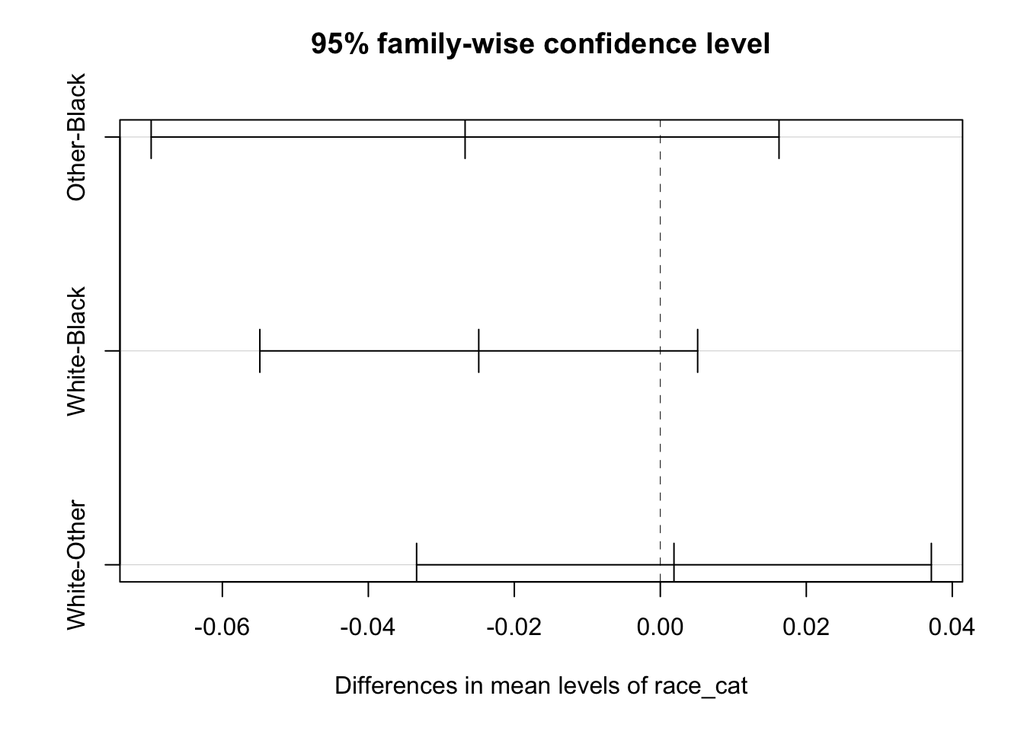

```r
plot(TukeyHSD(anova_race))
```

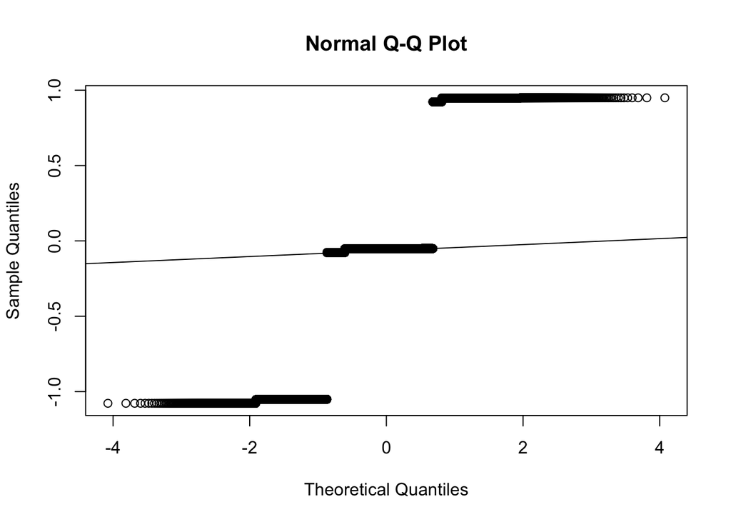

```r
# QQ plot of residuals
qqnorm(residuals(anova_race))
qqline(residuals(anova_race))
```

The **Normal QQ Plot** clearly shows that the residuals from the ANOVA model **do not follow a normal distribution**. The data points form distinct horizontal clusters (stair-step pattern) rather than following the theoretical straight line. This is expected because the dependent variable, `confinan` (Trust in Financial Institutions), is an **ordinal variable** with only three discrete values (1, 2, 3), violating the normality assumption required for a reliable ANOVA. This further supports the Chi-squared test’s finding (which is a non-parametric test suitable for categorical/ordinal data) as the more appropriate conclusion.

### t-Test: Differences by Ethnicity

```r
t.test(confinan ~ ethnicity_binary, data = gss_clean)
```

```
##
##  Welch Two Sample t-test
##
## data:  confinan by ethnicity_binary
## t = 2.1257, df = 3484.6, p-value = 0.0336
## alternative hypothesis: true difference in means between group Hispanic and group Not Hispanic is not equal to 0
## 95 percent confidence interval:
##  0.002285419 0.056577829
## sample estimates:
##     mean in group Hispanic mean in group Not Hispanic
##                   2.081798                   2.052366
```

The **t-test** compares the mean trust level in financial institutions between Hispanic and Not Hispanic groups. The test yielded a p-value of 0.0336. Since p<0.05, we **reject the null hypothesis**.  
**Takeaway:** There is a **statistically significant difference** in the mean trust level toward financial institutions between the Hispanic and Not Hispanic ethnic groups.

The analysis shows **statistically significant differences in trust toward financial institutions across both racial and ethnic groups.**

1. **Race (Categorical Association):** The Chi-squared test (p=0.0153) and the EDA consistently indicated that the **Black** group reports a **higher proportion of “Hardly any” trust** compared to the White group, suggesting significant differences in the distribution of trust. However, the ANOVA found **no significant difference in the mean trust scores** across the three racial groups (p=0.14), likely due to the ordinal nature of the data and the dominance of the “Some” trust category.
2. **Ethnicity (Mean Difference):** The t-test provided the clearest parametric evidence, showing a **statistically significant lower mean trust** in financial institutions among **Hispanic respondents** (mean=2.0818) compared to Not Hispanic respondents (mean=2.0524) (p=0.0336).

The consistent finding across both Chi-squared and t-test analyses is that **minoritized groups (Black and Hispanic)** in the GSS dataset exhibit a **lower level of trust** in financial institutions, particularly at the extremes (reporting “Hardly any” trust) and in the overall mean score for ethnicity.

## Bootstrap Confidence Intervals

```r
set.seed(123)
```

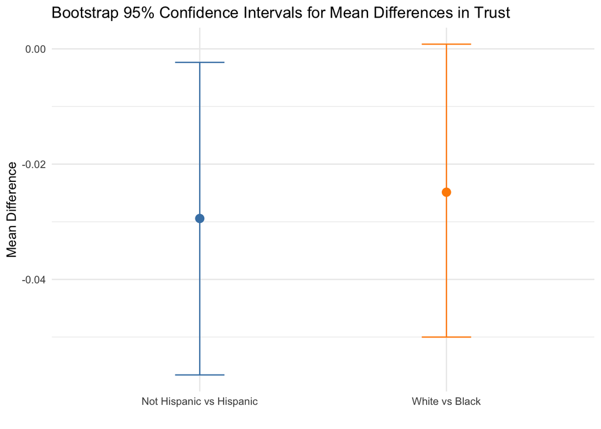

```r
gss_boot_race <- gss_clean %>% filter(!is.na(confinan) & !is.na(race_cat))
gss_boot_eth <- gss_clean %>% filter(!is.na(confinan) & !is.na(ethnicity_binary))

# functions for mean differences
mean_diff_race <- function(data, indices) {
  d <- data[indices, ]
  mean(d$confinan[d$race_cat == "White"]) - mean(d$confinan[d$race_cat == "Black"])
}

mean_diff_eth <- function(data, indices) {
  d <- data[indices, ]
  mean(d$confinan[d$ethnicity_binary == "Not Hispanic"]) -
    mean(d$confinan[d$ethnicity_binary == "Hispanic"])
}

boot_race <- boot(data = gss_boot_race, statistic = mean_diff_race, R = 5000)
boot_eth  <- boot(data = gss_boot_eth,  statistic = mean_diff_eth,  R = 5000)

ci_race <- boot.ci(boot_race, type = "perc")$percent[4:5]
ci_eth  <- boot.ci(boot_eth,  type = "perc")$percent[4:5]

boot_plot <- data.frame(
  Comparison = c("White vs Black", "Not Hispanic vs Hispanic"),
  MeanDiff   = c(
    mean(gss_boot_race$confinan[gss_boot_race$race_cat=="White"]) -
      mean(gss_boot_race$confinan[gss_boot_race$race_cat=="Black"]),
    mean(gss_boot_eth$confinan[gss_boot_eth$ethnicity_binary=="Not Hispanic"]) -
      mean(gss_boot_eth$confinan[gss_boot_eth$ethnicity_binary=="Hispanic"])
  ),
  Lower = c(ci_race[1], ci_eth[1]),
  Upper = c(ci_race[2], ci_eth[2])
)

library(ggplot2)
ggplot(boot_plot, aes(x = Comparison, y = MeanDiff, color = Comparison)) +
  geom_point(size = 3) +
  geom_errorbar(aes(ymin = Lower, ymax = Upper), width = 0.2) +
  labs(
    title = "Bootstrap 95% Confidence Intervals for Mean Differences in Trust",
    y = "Mean Difference",
    x = ""
  ) +
  theme_minimal() +
  scale_color_manual(values = c("steelblue", "darkorange")) +
  theme(legend.position = "none")
```

Based on the combined results:

1. **Chi-squared tests** reliably found a **significant association** between race/ethnicity and the *distribution* of trust, particularly showing **higher distrust** (“Hardly any” trust) among **Black** and **Hispanic** respondents.
2. **Parametric tests (ANOVA/t-test)** and the **Bootstrap CI plot** show that when looking at the *mean* trust score, the differences are small and, in the case of race, **not statistically significant** (ANOVA p=0.14; CI includes 0). The most robust evidence for difference in means comes from the t-test for ethnicity (p=0.0336).

# Time-series Analysis

## Cleaning

```r
trust_ext <- read_csv(
  "data/trust_in_government_by_race_and_ethnicity_data_2024-06-24.csv",
  skip = 2,
  col_names = c("Date", "Source", "Hispanic", "Black", "White", "Asian"),
  col_types = cols(
    Date = col_character(),
    Source = col_character(),
    Hispanic = col_double(),
    Black = col_double(),
    White = col_double(),
    Asian = col_double()
  )
)
trust_ext <- trust_ext %>%
  mutate(
    Date = str_remove(Date, " UTC"),
    Date = mdy(Date)
  ) %>%
  filter(!is.na(Date))
```

## EDA

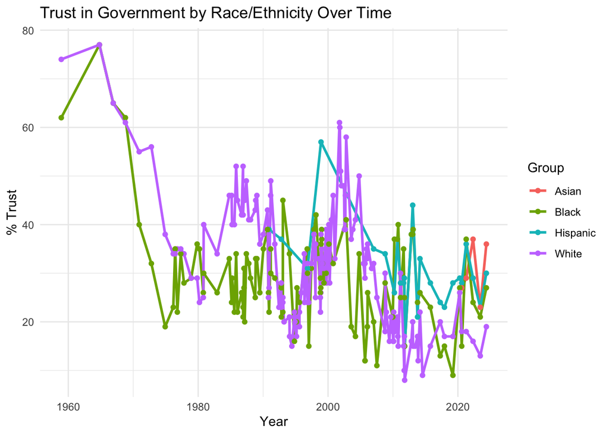

```r
trust_long <- trust_ext %>%
  pivot_longer(cols = c(Hispanic, Black, White, Asian),
               names_to = "Group", values_to = "Trust") %>%
  filter(!is.na(Trust))

ggplot(trust_long, aes(x = Date, y = Trust, color = Group)) +
  geom_line(size = 1) +
  geom_point(size = 1.5) +
  labs(title = "Trust in Government by Race/Ethnicity Over Time",
       x = "Year", y = "% Trust") +
  theme_minimal()
```

This line plot visualizes the percentage of respondents who report trusting the government (likely corresponding to “Always” or “Most of the time”) from approximately 1960 to the 2020s.

### Missing Data

```r
sapply(trust_ext[, c("Hispanic", "Black", "White", "Asian")], function(x) sum(is.na(x)))
```

```
## Hispanic    Black    White    Asian
##      125       46        0      146
```

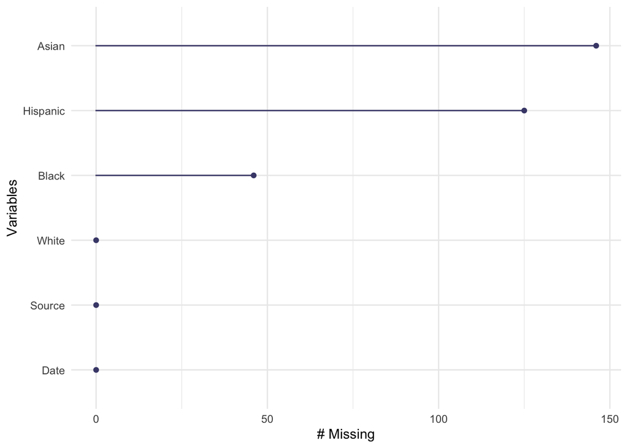

```r
gg_miss_var(trust_ext)
```

The missingness in the Hispanic, Black, and Asian groups justifies the decision to **focus the formal time-series modeling (ARIMA) solely on the White respondent group**, as their data is the most continuous and stable for building a predictive model.

## Prepare Time Series Object for White Respondents

```r
white_ts_data <- trust_ext %>%
  select(Date, White) %>%
  filter(!is.na(White)) %>%
  arrange(Date)

white_ts <- ts(white_ts_data$White,
               start = as.numeric(format(min(white_ts_data$Date), "%Y")),
               end = as.numeric(format(max(white_ts_data$Date), "%Y")),
               frequency = 1)
```

### Visualizing Time Series

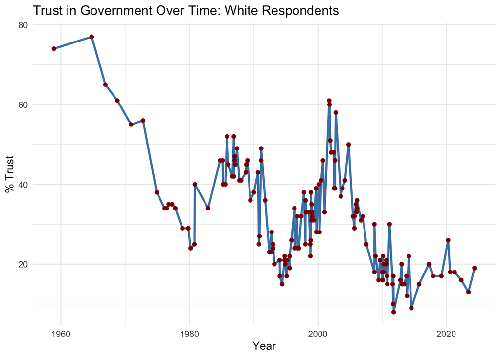

```r
ggplot(white_ts_data, aes(x = Date, y = White)) +
  geom_line(color = "steelblue", size = 1) +
  geom_point(color = "darkred") +
  labs(title = "Trust in Government Over Time: White Respondents",
       x = "Year", y = "% Trust") +
  theme_minimal()
```

The historical data is clearly **non-stationary** (the mean and variance change over time), confirming the need for the **ADF test** to determine if differencing is required before fitting the ARIMA model.

## ARIMA Model

```r
adf.test(white_ts)
```

```
##
##  Augmented Dickey-Fuller Test
##
## data:  white_ts
## Dickey-Fuller = -2.4677, Lag order = 4, p-value = 0.3852
## alternative hypothesis: stationary
```

```r
white_arima <- auto.arima(white_ts)
summary(white_arima)
```

```
## Series: white_ts
## ARIMA(0,1,0)
##
## sigma^2 = 49.58:  log likelihood = -222.47
## AIC=446.93   AICc=446.99   BIC=449.12
##
## Training set error measures:
##                      ME     RMSE      MAE       MPE     MAPE      MASE
## Training set -0.6257612 6.988269 5.105582 -3.320831 15.43518 0.9852878
##                   ACF1
## Training set -0.184997
```

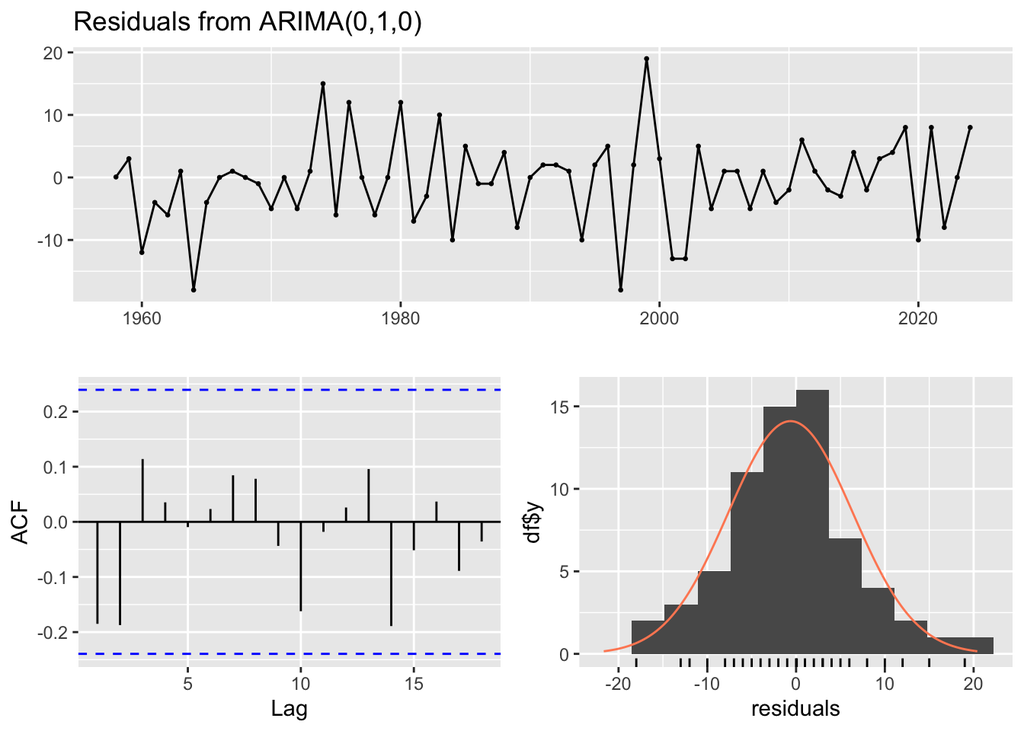

```
##
##  Ljung-Box test
##
## data:  Residuals from ARIMA(0,1,0)
## Q* = 9.2792, df = 10, p-value = 0.5058
##
## Model df: 0.   Total lags used: 10
```

```r
checkresiduals(white_arima)
```

Since the p-value (0.3852) is much greater than the significance level (α=0.05), we **fail to reject the null hypothesis** of non-stationarity. This confirms that the trust series for White respondents has a unit root, meaning its statistical properties (like the mean) change over time. This justifies the use of **first-differencing** in the ARIMA model, which is represented by the d=1 component.

**Residual Plot (Visuals):**

### Forecasting for Next 10 years

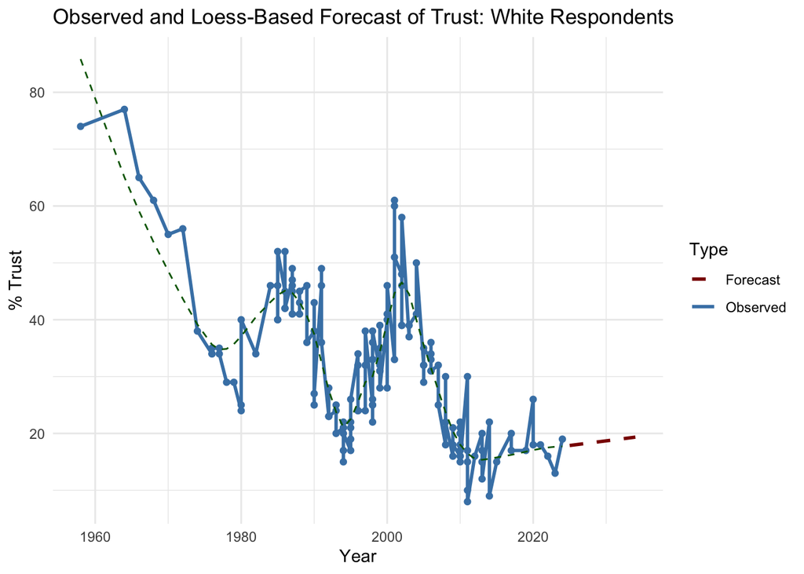

```r
white_ts_data <- white_ts_data %>%
  mutate(Year = as.numeric(format(Date, "%Y")))

loess_fit <- loess(White ~ Year, data = white_ts_data, span = 0.3)
white_ts_data <- white_ts_data %>%
  mutate(Loess_Fit = predict(loess_fit, newdata = white_ts_data))

future_years <- data.frame(Year = seq(max(white_ts_data$Year) + 1,
                                      by = 1, length.out = 10))

recent_slope <- coef(lm(Loess_Fit ~ Year, data = tail(white_ts_data, 5)))[2]
last_value <- tail(white_ts_data$Loess_Fit, 1)
future_trust <- last_value + recent_slope * (future_years$Year - max(white_ts_data$Year))

forecast_loess <- future_years %>%
  mutate(Trust = pmax(future_trust, 0)) %>%
  mutate(Type = "Forecast")

historical <- white_ts_data %>%
  select(Year, White, Loess_Fit) %>%
  rename(Trust = White) %>%
  mutate(Type = "Observed")

loess_plot <- bind_rows(
  historical %>% select(Year, Trust, Type),
  forecast_loess
)

ggplot() +
  geom_line(data = loess_plot, aes(x = Year, y = Trust, color = Type, linetype = Type), size = 1) +
  geom_point(data = historical, aes(x = Year, y = Trust), color = "steelblue") +
  geom_line(data = white_ts_data, aes(x = Year, y = Loess_Fit), color = "darkgreen", linetype = "dashed") +
  scale_color_manual(values = c("Observed" = "steelblue", "Forecast" = "darkred")) +
  scale_linetype_manual(values = c("Observed" = "solid", "Forecast" = "dashed")) +
  labs(title = "Observed and Loess-Based Forecast of Trust: White Respondents",
       x = "Year", y = "% Trust") +
  theme_minimal()
```

The LOESS-based forecast, which relies on the recently observed trends in the smoothed data, suggests that **trust in government among White respondents is projected to remain historically low over the next decade**. The model does not predict any significant recovery in trust, indicating that the modern baseline of low public confidence is expected to persist into the near future. This low-range persistence is consistent with the ARIMA(0,1,0) model, which identified the series as a random walk, implying that current levels are the best predictor for future levels.